# Tutorial 1 - Designing a social learning environment

Charley Wu and Wataru Toyokawa

2025-09-29

```r
packages <- c('tidyverse', "vembedr", 'formatR')
#invisible(lapply(packages, install.packages, character.only = TRUE)) #Install packages if any are missing
invisible(lapply(packages, require, character.only = TRUE)) #Load all packages
knitr::opts_chunk$set(warning = FALSE, message = FALSE)
set.seed(1234) #set seed for reproducibility
```

Welcome to tutorial 1 of [COSMOS summer school](https://cosmossummerschool.github.io/). These code notebooks are designed to be self-contained learning tools for building on the concepts taught during the summer school, but should also be accessible for anyone from around the world interested in these topics.

The code notebooks will introduce theoretical concepts, provide basic mathematical formulas, and helpful code snippets that you can use in your own projects. There are also links to demonstrations of simple online experiments and interactive [Shiny apps](https://shiny.rstudio.com/) that will allow you to play around with different experimental paradigms, computational models, and simulation frameworks. These notebooks will also contain exercises, which offer suggestions for how to go beyond the materials.

# Social learning problems

For both humans and animals, much of what we learn, we learn from others. Social information is cheap: we can expediently learn which actions will lead to reward or to punishment by observing others, instead of blundering our way through individual trial and error (Heyes, 2002; Hoppitt & Laland, 2013). Social information also has incredible depth (at least certainly for humans): we can extract complex inferences about the hidden goals, beliefs, and preferences of others from subtle patterns of behavior (Jara-Ettinger, 2019; Wu et al., 2022). Yet even simple social dynamics can give rise to intelligent group-level behavior (Berdahl et al., 2013), where challenging or impossible problems for a lone individual is no match for the power of a collective.

While researchers use a wide range of problems to study social learning and collective behavior, here, we focus on providing code and intuitions about how to implement the simplest possible social learning task: the multi-armed bandit problem. Later, we show how through minor tweaks, we can modify the same basic setting to create a galaxy of different social learning problems.

# Multi-armed bandit problem

Our first goal is to design a simple learning environment for studying social learning and collective behavior. We start with a *multi-armed bandit* problem (Robbins, 1952; Steyvers et al., 2009; Wald, 1947) as one of the simplest tasks commonly used to study learning in humans, animals, and artificial agents.

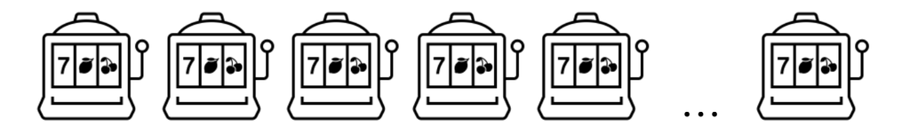

The term “multi-armed bandit” is simply a colorful metaphor for a row of slot machines in a casino. Since slot machines are notorious for stealing your money, they’re sometimes known as a “one-armed bandit”, in reference to the lever used to play the machine.

Each of the $k \in [1,\ldots, K]$ slot machines refer to one of $K$ different available decisions or options, each yielding a reward from an initially unknown payoff function. We can easily map this metaphor onto a wide range of real-world learning problems, such as choosing what to order at a restaurant, choosing where to forage for food, or choosing which crops to plant. The goal is thus to maximize your payoffs, by sequentially playing one of the options at each time $t$.

In order to do so, one must balance between **exploring** new options to acquire information about payoffs (to inform future decisions) and **exploiting** options known to have high-payoffs (in order to acquire immediate rewards). This is known as the **exploration-exploitation** dilemma (Mehlhorn et al., 2015) and every living organism capable of learning must achieve an efficient balance to these dual goals. Yet, given a finite time horizon for learning, optimal solutions are generally unavailable (Aplin et al., 2015; Deffner et al., 2020; Sasaki et al., 2013).

## 2-armed Gaussian bandits

Let’s start from the simplest case and program a 2-armed bandit with Gaussian rewards. Imagine you are a farmer, and can choose to either plant one of two crops: wheat vs. potato. At the end of the growing season, you then earn a reward proportional to how well your crop performed. However, one of the crops may produce reliably better yields, and it is up to the farmer to figure out which crop is better.

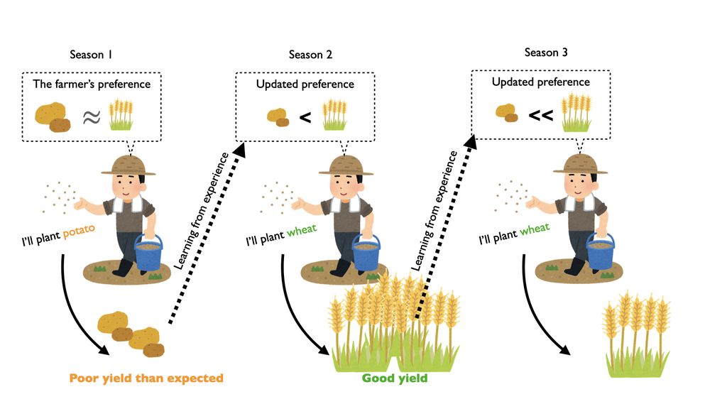

The farmer may experience better yields or poorer yields depending on the choice of crops as well as some raddom noise from the environment.

Year after year, there may be variations in yield for a given crop, which we can model using *Gaussian noise*. Thus, we can describe the reward for option $k$ as a sample from a Gaussian distribution (also known as a Normal distribution, hence the fancy $\mathcal{N}$):

$$r_k \sim \mathcal{N}(\mu_k, \sigma_k^2)$$

We can now describe a payoff function for each option in terms of a mean or **expected reward** $\mu_k$ and the **variability** $\sigma_k^2$ (expressed as a variance). Note that the variability can also be expressed in terms of a standard deviation as $\sigma_k = \sqrt{\sigma_k^2}$.

(*Note*: people using MacOS Ventura may have issues rendering the equations due to changes in the font library. If you see a box instead of a fancy N, then you can fix the issue using selecting the box > right-click > Math Settings > Math Renderer > “Common HTML”).

## Generative model of the environment

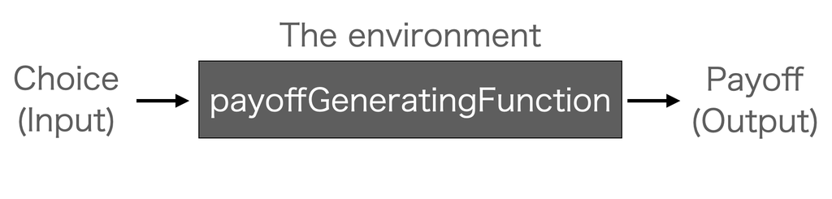

A generative model of the environment takes a choice as an input and returns a payoff as an output.

Let’s now program a *generative model* of the bandit task. By defining the number of options, and providing the expected reward and variability for each option, we can define a function that takes an action and returns a reward. We provide the function in the code block below and generate payoffs for 25 random choices.

```r
K = 2 #number of options
meanVec <- runif(n=K, min = -10, max = 10) #Payoff means, which we sample from uniform distribution between -10 to 10
sigmaVec <- rep(1, K) #Variability of payoffs (as a standard deviation), which we assume is the same for all options.

banditGenerator <- function(k) {#k is an integer or k vector of integers, selecting one of the 1:K arms of the bandit
  payoff <- rnorm(n = length(k), mean = meanVec[k], sd = sigmaVec[k])
  return (payoff)
}

actionSequence <- sample(1:K, size = 25, replace = TRUE) # select 25 random actions
payoffs <- banditGenerator(actionSequence)

df <- data.frame(action = actionSequence, payoff = payoffs)
knitr::kable(df)
```

| action | payoff |
| --- | --- |
| 2 | 3.8159985 |
| 2 | 0.7586613 |
| 1 | -8.3533680 |
| 2 | 2.4643047 |
| 1 | -7.0206883 |
| 1 | -8.3729508 |
| 1 | -6.8577509 |
| 2 | 2.8216237 |
| 2 | 2.7562503 |
| 2 | 2.4509950 |
| 2 | 2.4083578 |
| 1 | -7.0019557 |
| 2 | 1.9492492 |
| 2 | 2.4573833 |
| 2 | 2.4558480 |
| 1 | -7.0476604 |
| 2 | 3.4755511 |
| 2 | 0.7164596 |
| 2 | 0.2416400 |
| 2 | 2.9891610 |
| 2 | 2.4674153 |
| 2 | 2.6085539 |
| 2 | 3.6877424 |
| 2 | 3.2287656 |
| 1 | -7.6778111 |

Let’s now visualize the environment, where we use a large number of samples (n=10000) to paint an accurate picture of the true generative reward structure (vertical density plot), and plot that against a small number (n=25) of sampled payoffs (dots):

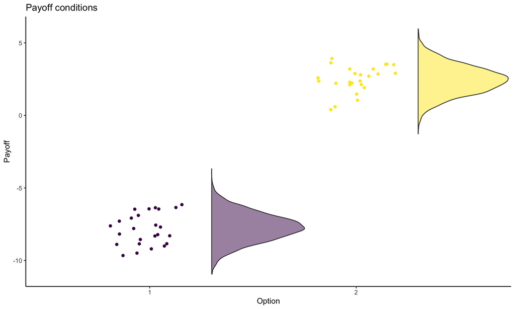

```r
source('codeSnippets/geom_flat_violin.R')
# Use samples to approximate the reward distribution
sampleDF <- data.frame()
nsamples = 10000 #Samples used to approximate the normal distribution
plotsamples = 25 #samples to plot as dots

rewardSamples <- c(sapply(1:K, FUN=function(k) banditGenerator(rep(k, nsamples))))#use an apply function to simulate multiple samples of each arm
sampleDF <- data.frame(option = rep(1:K, each = nsamples), payoff=rewardSamples, nsample = rep(1:nsamples, K)) #create a dataframe for plotting

ggplot(sampleDF, aes(x = factor(option), y = payoff, fill = factor(option)))+
  geom_flat_violin(position = position_nudge(x = 0.3, y = 0), alpha = .5) +
  geom_jitter(data = subset(sampleDF, nsample<=plotsamples), aes(y = payoff, color = factor(option)),width = 0.2 )+  #Plot only a subset of points show how well a limited number of samples approximates the true distribution
  ylab('Payoff')+
  xlab('Option')+
  theme_classic() +
  scale_fill_viridis_d()+
  scale_color_viridis_d()+
  ggtitle('Payoff conditions')+
  theme(legend.position ='none')
```

## Scaling up

Of course, a 2-armed bandit is quite a simple learning environment. But we can very easily scale up the number of options. How many trials do you think it would take you to identify the best option below?

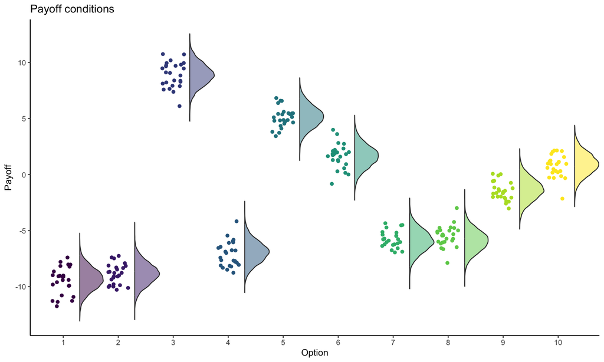

```r
#define larger set of option
K <- 10
meanVec <- runif(n=K, min = -10, max = 10) #Payoff means, which we sample from uniform distribution between -10 to 10
sigmaVec <- rep(1, K)

# Use samples to approximate the reward distribution
sampleDF <- data.frame()
nsamples = 10000 #Samples used to approximate the normal distribution
plotsamples = 25 #samples to plot as dots

rewardSamples <- c(sapply(1:K, FUN=function(k) banditGenerator(rep(k, nsamples))))#use an apply function to simulate multiple samples of each arm
sampleDF <- data.frame(option = rep(1:K, each = nsamples), payoff=rewardSamples, nsample = rep(1:nsamples, K)) #create a dataframe for plotting

ggplot(sampleDF, aes(x = factor(option), y = payoff, fill = factor(option)))+
  geom_flat_violin(position = position_nudge(x = 0.3, y = 0), alpha = .5) +
  geom_jitter(data = subset(sampleDF, nsample<=plotsamples), aes(y = payoff, color = factor(option)),width = 0.2 )+  #Plot only a subset of points show how well a limited number of samples approximates the true distribution
  ylab('Payoff')+
  xlab('Option')+
  theme_classic() +
  scale_fill_viridis_d()+
  scale_color_viridis_d()+
  ggtitle('Payoff conditions')+
  theme(legend.position ='none')
```

**Exercise 1.1.** Can you modify the payoff generating function to describe other tasks? Sometimes rewards are binary, such as with success or failure outcomes when publishing a paper or hunting for food. With binary reward structures, you can use a Bernoulli distribution in place of a Gaussian distribution. The code snippet below contains a brief example.

```r
K <- 10
successVec = runif(K) #different success probabilities for each option sampled from a uniform distribution between 0 and 1
binaryGenerator <- function(k) {#k is an integer or k vector of integers, selecting one of the 1:K arms of the bandit
  payoff <- rbernoulli(n = length(k), p=successVec[k]) #a Bernoulli distribution can be used to describe a binary reward structure
  return (payoff)
}
binaryGenerator(sample(1:10, 25, replace = TRUE))
```

# Live demonstrations

Let’s now dive in and experience learning and exploration for yourself!

## Individual learning

We will start with a simple individual learning version of the task, where you’ll each be on your own. Think about how you learn which options provide the best rewards and how you navigate the explore-exploit dilemma.

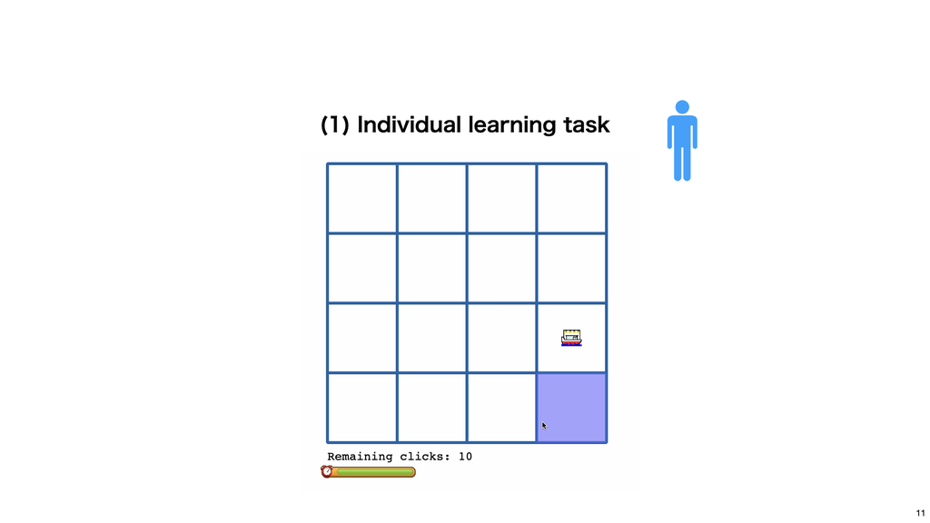

A 16-armed bandit task.

The demo game is an 16-armed bandit task. Suppose you are in the fishing boat and trying to catch as many fish as possible. The ocean is divided into the 16 grid cells. Some grid areas will provide more fish than other grid areas. To make a decision, just click/tap one of the cells.

**[Individual learning experiment](http://tk2-127-63496.vs.sakura.ne.jp:8989/)**

**Exercise 1.2.** At the end of the experiment, you can download the results. Once you have finished tutorial 2, try fitting a reinforcement learning model on your data and see which parameters best describe your data. What potential limitations do you think there will be with fitting a model on about 10 trials of data?

## Social learning

Now, let’s switch to a social version of the task. Beyond simply learning from your own experiences, you can observe the actions of others and use that to inform your decisions. Here, we start with the simplest case where all players are interacting with the exact same reward function. Of course, this isn’t always the case in the real world, but it is the simplest starting point.

You will be able to observe the actions of other players, but not see the rewards they earn (Toyokawa & Gaissmaier, 2022). Do you think that collectively, you will be able to identify the best option? When do you think social learning will outperform individual learning, and when would it fail (Toyokawa et al., 2019)?

**[Social learning experiment](http://tk2-127-63496.vs.sakura.ne.jp:8989/?condition=group)**

**Exercise 1.3.** Once again, you can download the results after the experiment, but this time it will contain social information. After completing tutorial 2, try to fit a social reinforcement learning model on the data and see which parameters best describe you and the rest of your group.

## Competitive social learning (if time)

We now add a small twist to the social version of the task. As in many real-world examples of crowded tourist destinations or crowded watering holes, high-value options will tend to attract many individuals seeking rewards. Yet as the number of individuals increases, the rewards can decrease due to social competition. Here, we’ve implemented a simple version of social competition, where everyone who selects the same option will need to split the reward amongst one another. How will this change the social learning dynamics? Can you still use social information to learn about which options are rewarding? What strategies can you use to avoid unncessary competition?

**[Competitive social learning experiment](http://tk2-127-63496.vs.sakura.ne.jp:8989/?condition=competitive)**

**Exercise 1.4.** Can you also modify the payoff generating function we provided above to allow for multiple participants, each with their own noisy observation. You could also describe social competition between individuals who choose the same option via reward splitting as we described above.

# A galaxy of social learning problems

While we have focused on a very simple multi-armed bandit task, it also offers a high-degree of versatility. We have hinted at several tweaks to the paradigm in some exercises above, but we will now draw some more concrete connections to other domains for studying social learning.

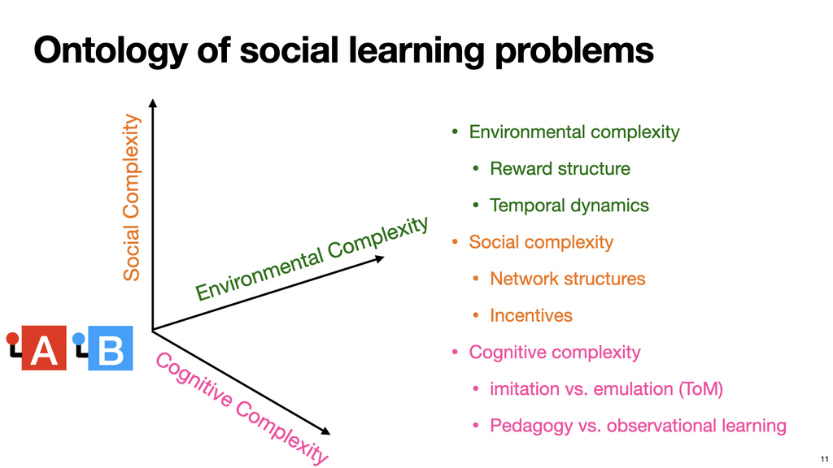

Ontology of social learning problems

## Environmental complexity

### Spatial structure

Many social interactions unfold in spatial settings, where both social information (Sridhar et al., 2021) and rewards are defined by spatial structure (Hawkins et al., in press). For instance, high-valued rewards may tend to be clustered together, such like good restaurants in a hip part of a city or prey/vegetation naturally occurring in patchy distributions.

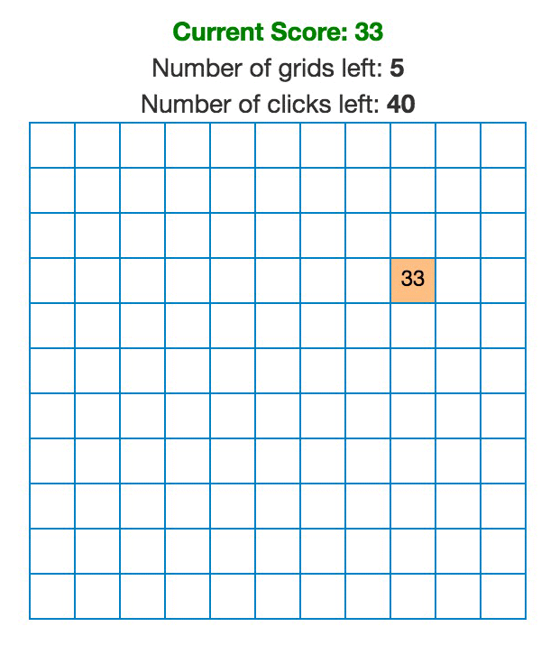

Spatially correlated bandit task from Wu et al. (2018)

One paradigm that adds spatial structure to bandit tasks is the “spatially correlated bandit” (Wu et al., 2018). Whereas bandit tasks typically assume that the rewards for each option are completely independent from all other options, the spatially correlated bandit places up to 121 options onto a 2D grid and informs participants options tend to have similar rewards to other nearby options. The spatial structure of rewards can be used (by people as young as age 5: Giron et al., 2023) to guide exploration towards promising regions of the search space. With the following link, you can try a version of the task where the rewards were derived from the yield of various crops on an experimental farm, such that the rows and columns of the grid correspond to the rows and columns of a field (see Exp. 3 in Wu et al., 2018 for details):

**[Spatially correlated bandit experiment](https://experiments.hmc-lab.com/gridsearch3/MAB.html)**

More recently, Wu et al. (2025) developed an immersive variant of the task with collective foraging dynamics. Participants are tasked with foraging for binary rewards (indicated by a blue splash), and in the condition below, rewards are clustered together. This means that observing another player acquire a reward provides a valuable social signal that there are likely to be other rewards nearby:

**Task tutorial**

```r
embed_url("https://www.youtube.com/watch?v=QksKYOoElxg")
```

[video not shown]

**POV video from social round with smooth rewards**

```r
embed_url("https://www.youtube.com/watch?v=wyk7RbmHiok")
```

[video not shown]

### Depleting reward (foraging tasks)

Much research on social learning has used the naturalistic context of foraging, where an organism can use social cues to help find food or other important resources (Giraldeau & Caraco, 2018; Hoppitt & Laland, 2013; Zentall et al., 1988). Foraging tasks can be framed as a special kind of multi-armed bandit, where the dynamics of the natural world mean that rewards are typically finite and diminish over time. Just as bandits simply decision-making problems into a discrete number of choices, research on foraging also simplifies the natural world into a discrete number of patches. For instance, in this illustration of a producer-scrounger task (Barnard & Sibly, 1981), experimenters place food pellets in a limited number of wells on a grid and observe how animals engage in either individual learning (“producer” strategy) or social imitation (“scrounger” strategy). We will be discussing the dynamics of different learning strategies in more detail in Tutorial 2.

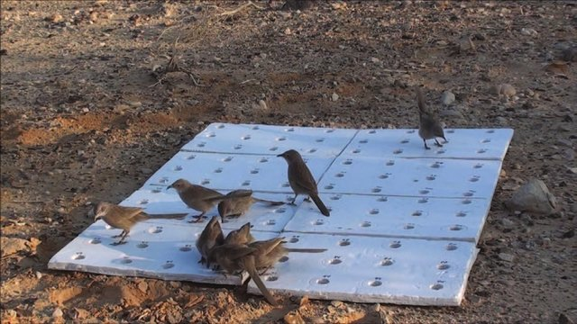

Producer-Scrounger task from Keynan et al. (2015)

**Exercise 1.5.** Can you modify the bandit generator to capture the dynamics of a foraging task and produce diminishing returns? For instance, each time an option is chosen, the expected rewards could decays towards 0. This might mimic a real “foraging” situation where there are only limited amounts of food in each patch. You may need to use a different reward distribution than a Gaussian, since rewards are typically non-negative (but not always, since some resources can inflict harm; i.e., eating rotten food).

### Dynamic Landscape

Beyond only foraging and learning in spatial environments, we also want to describe social learning problems in more open-ended, dynamic environments. One method for describing social learning along environmental changes is to a **dynamic fitness landscape**. Originally introduced in the 1930s to study genetic evolution, fitness landscapes can also be used to map any combination of latent features to some fitness value. Learning can thus be compared to an optimization (“hill climbing”) process as an organism learns to acquire better solutions through a combination of both individual and social learning (Barkoczi et al., 2016; Mason & Watts, 2012).

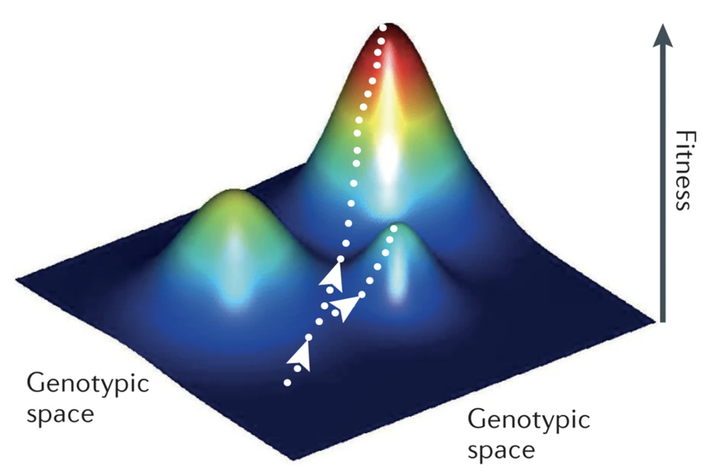

from De Visser & Krug (2014)

Experiments showed that fish schools could keep track preferred darkness in a variable-light environment (Berdahl et al., 2013), with a similar collective sensing being also reported in human experiments (Hawkins et al., in press).

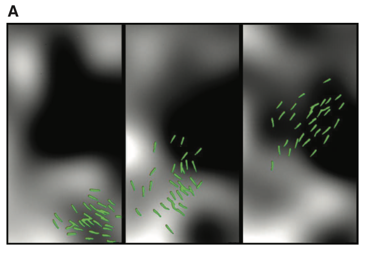

from Berdahl et al. (2013)

This is still quite similar to how the spatially correlated bandit (Wu et al., 2018) maps each of the options onto a 2D grid. The main difference is that a fitness landscape introduces an arbitrary number of dimensions that may have abstract rather than spatial relationships between options or “locations” on the search space. And while there are many similarities in how people learn and search in spatial vs. non-spatial environments, there are also important differences (Wu et al., 2020). For instance, compared to learning spatially correlated rewards, Wu et al. (2020) found that participants explored in a distinctly different fashion when learning on the exact same reward structure, but the with x- and y-dimensions mapped instead onto the tilt and stripe frequency of a Gabor patch.

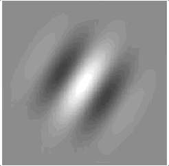

from Wu et al. (2020)

## Social complexity

### Individual Preferences

Much research on social learning has focused on settings where everyone has identical goals and preferences. But in the real world, that’s rarely the case. Whether we’re choosing restaurants, planning holidays, or making career moves, the individuals we rely on for advice often have their own, unique tastes and circumstances. Similar to the spatially correlated bandit, you can think about a **socially correlated** bandit tasks where the bandit landscapes are similar, but not identical, across participants (Witt et al., 2024). Witt et al. (2024) found that people used social information as an exploration tool, but “with a grain of salt” — in the experiment, they treated social information as noisier, and thus less reliable, than information they collected themselves.

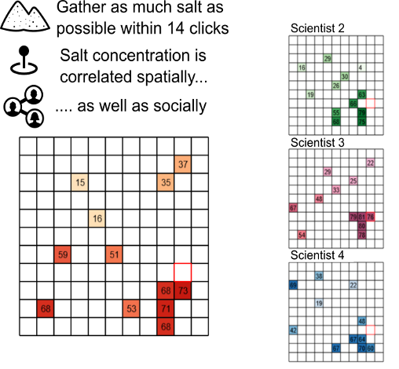

from Witt et al. (2024)

### Social Networks

Collective behavior is formed not only by the individual-level social learning strategies, but also by how individuals are connected to each other. It has been suggested that balancing the “exploration vs. exploitation” is regulated by the social network structures, with sparse inefficient connections promoting exploration while dense networks could lead exploitation Cantor et al. (2021). Importantly, learning strategies of individuals can also be flexible, responding to the network structure they are embedded. Jiang et al. (2023) showed that human social learning is flexibly weighted toward well-connected neighbors.

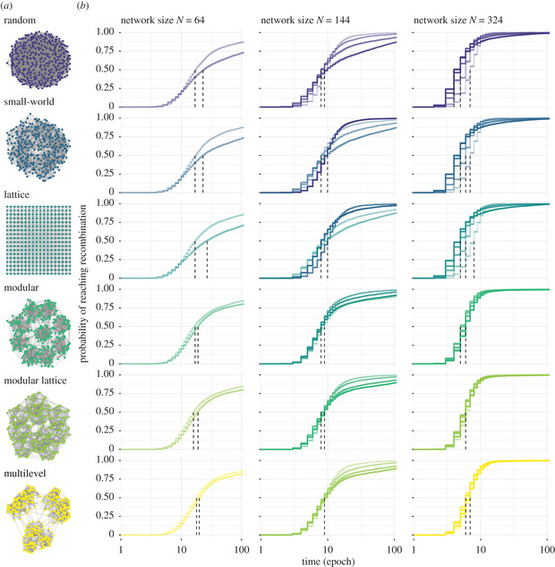

from Cantor et al. (2021)

## Cognitive complexity

### Theory of Mind

Thus far, we have described some of the simplest social learning mechanisms that could be well approximated by a simple stimulus-response learning. However, humans have some ability to “unpack” observed actions into imputed mental states using Theory of Mind (ToM). We can describe ToM as a form of inference, where observed behaviors are used to infer a variety of different mental representations.

### Pedagogy and Teaching

Theory of Mind is especially powerful in pedagogical contexts. Teaching enables humans to impart vast stores of culturally specific knowledge and skills. Vélez et al. (2023) found that human teachers choose examples that would maximize a learner’s belief in a target concept, while also taking their own preferences and communicative costs into account, suggesting how we could balance the own cost-benefit calculation and Tom simultaneously.

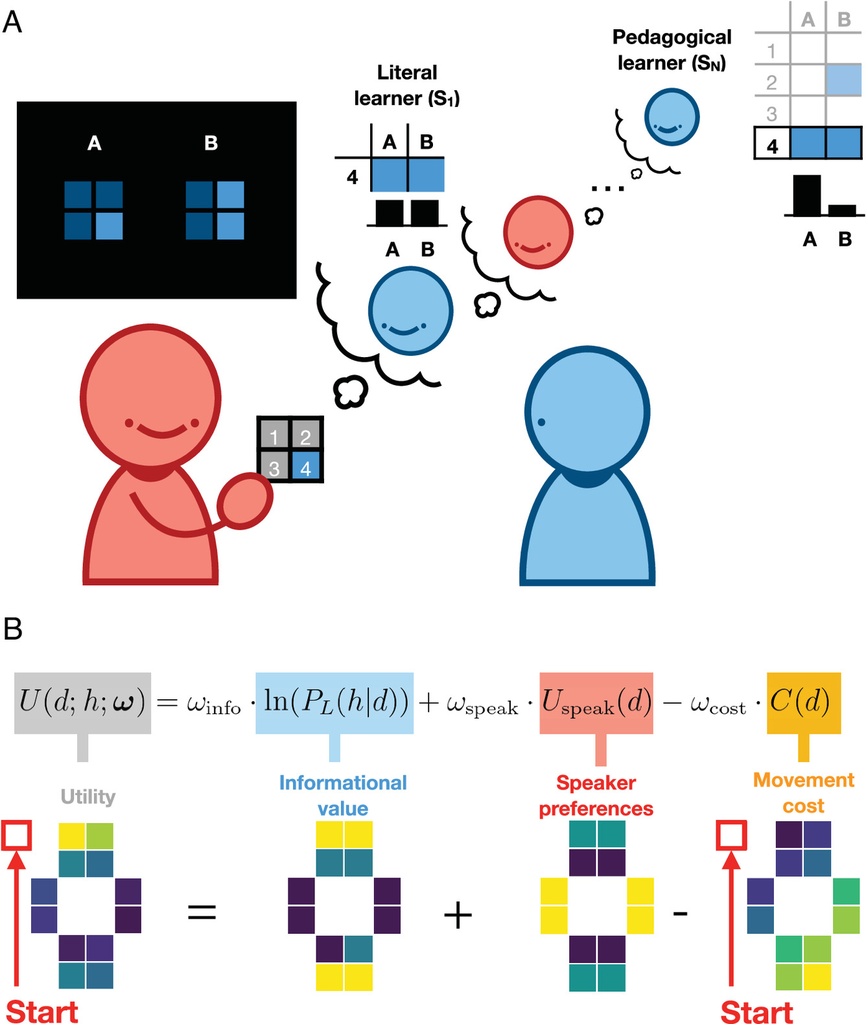

from Vélez et al. (2023)

## Combining dimensions

### Cumulative Cultural Evolution

Cumulative cultural evolution is driven by open-ended, accumulated innovations such as creation of new behaviors (Miu et al., 2018) or inventing new tools (Mesoudi & O’Brien, 2008). A bulk of empirical and theoretical studies have shown that a high-fidelity knowledge transmission is key to generate cumulative culture (Morgan et al., 2015). Although bandit tasks seem to be too limited to capture a full depth of such open-ended cultural evolutionary dynamics, some models have tried to study the evolutionary condition of cumulative cultural evolution using an *evolving* bandit where payoffs of each option can be modified through innovations (Castro & Toro, 2014).

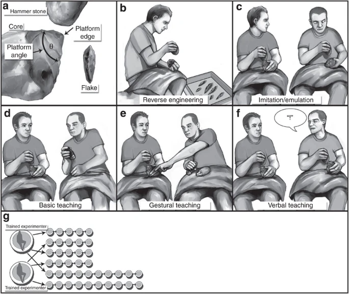

from Morgan et al. (2015)

# References

Aplin, L. M., Farine, D. R., Morand-Ferron, J., Cockburn, A., Thornton, A., & Sheldon, B. C. (2015). Experimentally induced innovations lead to persistent culture via conformity in wild birds. *Nature*, *518*(7540), 538–541.

Barkoczi, D., Analytis, P. P., & Wu, C. M. (2016). Collective search on rugged landscapes: A crossenvironmental analysis. In A. Papafragou, D. Grodner, D. Mirman, & J. C. Trueswell (Eds.), *Proceedings of the 38th Annual Conference of the Cognitive Science Society* (pp. 918–923). Cognitive Science Society.

Barnard, C. J., & Sibly, R. M. (1981). Producers and scroungers: A general model and its application to captive flocks of house sparrows. *Animal Behaviour*, *29*(2), 543–550.

Berdahl, A., Torney, C. J., Ioannou, C. C., Faria, J. J., & Couzin, I. D. (2013). Emergent sensing of complex environments by mobile animal groups. *Science*, *339*(6119), 574–576.

Cantor, M., Chimento, M., Smeele, S. Q., He, P., Papageorgiou, D., Aplin, L. M., & Farine, D. R. (2021). Social network architecture and the tempo of cumulative cultural evolution. *Proceedings of the Royal Society B*, *288*(1946), 20203107.

Castro, L., & Toro, M. A. (2014). Cumulative cultural evolution: The role of teaching. *Journal of Theoretical Biology*, *347*, 74–83.

De Visser, J., & Krug, J. (2014). Empirical fitness landscapes and the predictability of evolution. *Nature Reviews Genetics*, *15*(7), 480–490.

Deffner, D., Kleinow, V., & McElreath, R. (2020). Dynamic social learning in temporally and spatially variable environments. *Royal Society Open Science*, *7*(12), 200734.

Giraldeau, L.-A., & Caraco, T. (2018). Social foraging theory. In *Social foraging theory*. Princeton University Press.

Giron, A. P., Ciranka, S., Schulz, E., Bos, W. van den, Ruggeri, A., Meder, B., & Wu, C. M. (2023). Developmental changes in exploration resemble stochastic optimization. *Nature Human Behaviour*. https://doi.org/10.1038/s41562-023-01662-1

Hawkins, R. D., Berdahl, A. M., Pentland, A., Tenenbaum, J. B., Goodman, N. D., Krafft, P., et al. (in press). Flexible social inference facilitates targeted social learning when rewards are not observable. *Nature Human Behaviour*.

Heyes, C. (2002). Transformational and associative theories of imitation. *Imitation in Animals and Artifacts*, 501.

Hoppitt, W., & Laland, K. N. (2013). Social learning. In *Social learning*. Princeton University Press.

Jara-Ettinger, J. (2019). Theory of mind as inverse reinforcement learning. *Current Opinion in Behavioral Sciences*, *29*, 105–110.

Jiang, Y., Mi, Q., & Zhu, L. (2023). Neurocomputational mechanism of real-time distributed learning on social networks. *Nature Neuroscience*, *26*(3), 506–516.

Keynan, O., Ridley, A. R., & Lotem, A. (2015). Social foraging strategies and acquisition of novel foraging skills in cooperatively breeding arabian babblers. *Behavioral Ecology*, *26*(1), 207–214.

Mason, W., & Watts, D. J. (2012). Collaborative learning in networks. *Proceedings of the National Academy of Sciences*, *109*(3), 764–769.

Mehlhorn, K., Newell, B. R., Todd, P. M., Lee, M. D., Morgan, K., Braithwaite, V. A., Hausmann, D., Fiedler, K., & Gonzalez, C. (2015). Unpacking the exploration–exploitation tradeoff: A synthesis of human and animal literatures. *Decision*, *2*, 191–215.

Mesoudi, A., & O’Brien, M. J. (2008). The cultural transmission of great basin projectile-point technology i: An experimental simulation. *American Antiquity*, *73*(1), 3–28.

Miu, E., Gulley, N., Laland, K. N., & Rendell, L. (2018). Innovation and cumulative culture through tweaks and leaps in online programming contests. *Nature Communications*, *9*(1), 1–8.

Morgan, T. J., Uomini, N. T., Rendell, L. E., Chouinard-Thuly, L., Street, S. E., Lewis, H. M., Cross, C. P., Evans, C., Kearney, R., Torre, I. de la, et al. (2015). Experimental evidence for the co-evolution of hominin tool-making teaching and language. *Nature Communications*, *6*(1), 6029.

Robbins, H. (1952). Some aspects of the sequential design of experiments. *Bulletin of the American Mathematical Society*, *58*, 527–535.

Sasaki, T., Granovskiy, B., Mann, R. P., Sumpter, D. J., & Pratt, S. C. (2013). Ant colonies outperform individuals when a sensory discrimination task is difficult but not when it is easy. *Proceedings of the National Academy of Sciences*, *110*(34), 13769–13773.

Sridhar, V. H., Li, L., Gorbonos, D., Nagy, M., Schell, B. R., Sorochkin, T., Gov, N. S., & Couzin, I. D. (2021). The geometry of decision-making in individuals and collectives. *Proceedings of the National Academy of Sciences*, *118*(50), e2102157118.

Steyvers, M., Lee, M. D., & Wagenmakers, E.-J. (2009). A Bayesian analysis of human decision-making on bandit problems. *Journal of Mathematical Psychology*, *53*, 168–179.

Toyokawa, W., & Gaissmaier, W. (2022). Conformist social learning leads to self-organised prevention against adverse bias in risky decision making. *Elife*, *11*, e75308.

Toyokawa, W., Whalen, A., & Laland, K. N. (2019). Social learning strategies regulate the wisdom and madness of interactive crowds. *Nature Human Behaviour*, *3*(2), 183–193.

Vélez, N., Chen, A. M., Burke, T., Cushman, F. A., & Gershman, S. J. (2023). Teachers recruit mentalizing regions to represent learners’ beliefs. *Proceedings of the National Academy of Sciences*, *120*(22), e2215015120.

Wald, A. (1947). *Sequential analysis*. Wiley, New York.

Witt, A., Toyokawa, W., Lala, K. N., Gaissmaier, W., & Wu, C. M. (2024). Humans flexibly integrate social information despite interindividual differences in reward. *Proceedings of the National Academy of Sciences*, *121*(39), e2404928121.

Wu, C. M., Deffner, D., Kahl, B., Meder, B., Ho, M. K., & Kurvers, R. H. (2025). Adaptive mechanisms of social and asocial learning in immersive foraging environments. *Nature Communications*, *16*, 3539. https://doi.org/10.1038/s41467-025-58365-6

Wu, C. M., Schulz, E., Garvert, M. M., Meder, B., & Schuck, N. W. (2020). Similarities and differences in spatial and non-spatial cognitive maps. *PLOS Computational Biology*, *16*, 1–28. https://doi.org/10.1371/journal.pcbi.1008149

Wu, C. M., Schulz, E., Speekenbrink, M., Nelson, J. D., & Meder, B. (2018). Generalization guides human exploration in vast decision spaces. *Nature Human Behaviour*, *2*, 915--924. https://doi.org/10.1038/s41562-018-0467-4

Wu, C. M., Vélez, N., & Cushman, F. A. (2022). Representational exchange in human social learning: Balancing efficiency and flexibility. In I. C. Dezza, E. Schulz, & C. M. Wu (Eds.), *The Drive for Knowledge: The Science of Human Information-Seeking*. Cambridge University Press.

Zentall, T. R., Galef, B. G., et al. (1988). *Social learning: Psychological and biological perspectives*. Psychology Press.